# DA 460 - Lab 4

Marjorie Blanco

07 July, 2018

# Handout 4 R: Foundations for statistical inference - Sampling distributions

## The data

```r
# load data
download.file("http://www.openintro.org/stat/data/ames.RData", destfile = "ames.RData")
load("ames.RData")
```

```r
# the above ground living area of the house in square feet
area <- ames$Gr.Liv.Area
# the sale price
price <- ames$SalePrice

# summary statistics for area
summary(area)
```

```
##    Min. 1st Qu.  Median    Mean 3rd Qu.    Max.
##     334    1126    1442    1500    1743    5642
```

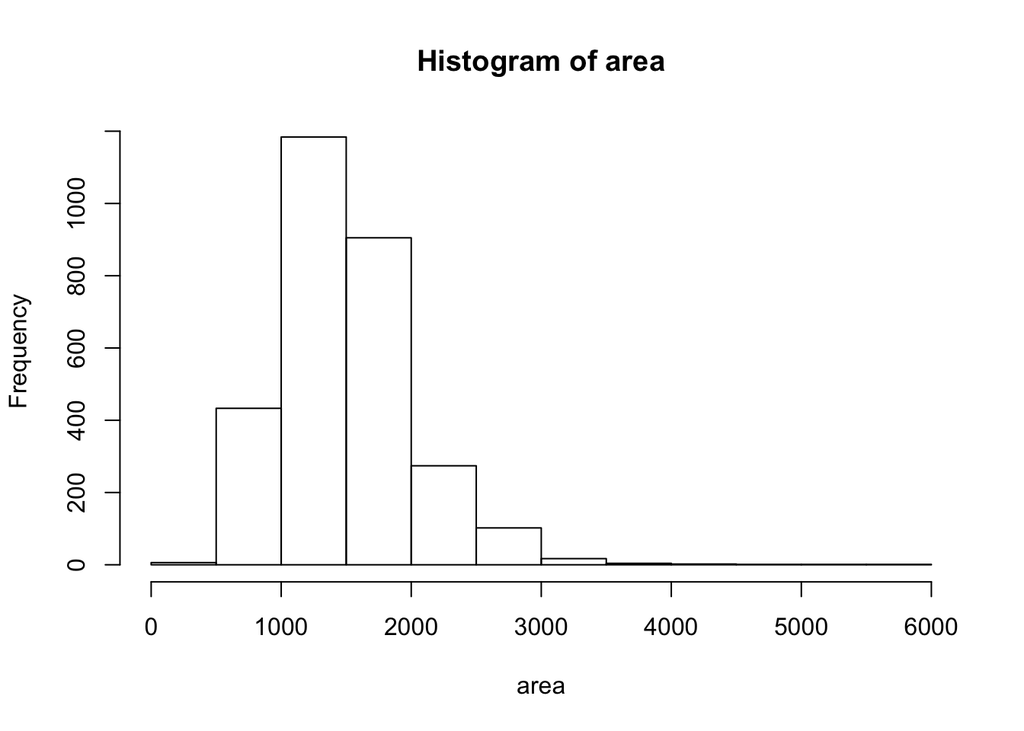

```r
# histogram for area
hist(area)
```

### Exercise 1

Describe this population distribution.

## The unknown sampling distribution

```r
# simple random sample of size 50
samp1 <- sample(area, 50)
```

### Exercise 2

Describe the distribution of this sample. How does it compare to the distribution of the population?

```r
# estimate the average living area in homes in Ames
mean(samp1)
```

```
## [1] 1639.82
```

### Exercise 3

Take a second sample, also of size 50, and call it samp2. How does the mean of samp2 compare with the mean of samp1? Suppose we took two more samples, one of size 100 and one of size 1000. Which would you think would provide a more accurate estimate of the population mean?

```r
# simple random sample of size 50
samp2 <- sample(area, 50)
# simple random sample of size 100
samp100 <- sample(area, 100)
# simple random sample of size 1000
samp1000 <- sample(area, 1000)


mean(samp2)
```

```
## [1] 1373.48
```

```r
mean(samp100)
```

```
## [1] 1551.28
```

```r
mean(samp1000)
```

```
## [1] 1507.671
```

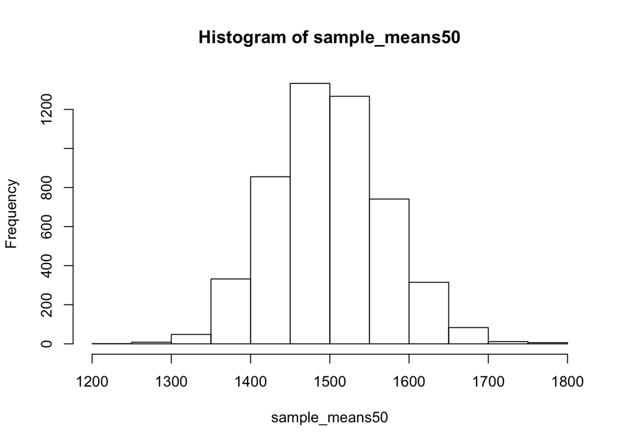

```r
# create vector to save mean for 5000 samples of size 50
sample_means50 <- rep(NA, 5000)

for(i in 1:length(sample_means50)){
   # simple random sample of size 50
   samp <- sample(area, 50)
   # save sample
   sample_means50[i] <- mean(samp)
   }
# histogram of mean for 5000 samples of size 50
hist(sample_means50)
```

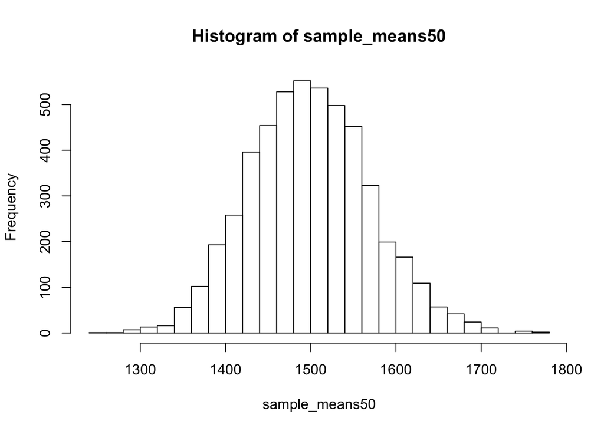

```r
# adjust the bin width of  histogram to show more detail
hist(sample_means50, breaks = 25)
```

### Exercise 4

How many elements are there in sample_means50? Describe the sampling distribution, and be sure to specifically note its center. Would you expect the distribution to change if we instead collected 50,000 sample means?

## Interlude: The for loop

```r
sample_means50 <- rep(NA, 5000)

samp <- sample(area, 50)
sample_means50[1] <- mean(samp)

samp <- sample(area, 50)
sample_means50[2] <- mean(samp)

samp <- sample(area, 50)
sample_means50[3] <- mean(samp)

samp <- sample(area, 50)
sample_means50[4] <- mean(samp)


sample_means50 <- rep(NA, 5000)

for(i in 1:5000){
   samp <- sample(area, 50)
   sample_means50[i] <- mean(samp)
   #print(i)
}
```

### Exercise 5

To make sure you understand what you’ve done in this loop, try running a smaller version. Initialize a vector of 100 zeros called sample_means_small. Run a loop that takes a sample of size 50 from area and stores the sample mean in sample_means_small, but only iterate from 1 to 100. Print the output to your screen (type sample_means_small into the console and press enter). How many elements are there in this object called sample_means_small? What does each element represent?

```r
sample_means_small <- rep(NA, 100)

for(i in 1:length(sample_means_small)){
   samp <- sample(area, 50)
   sample_means_small[i] <- mean(samp)
}
```

## Sample size and the sampling distribution

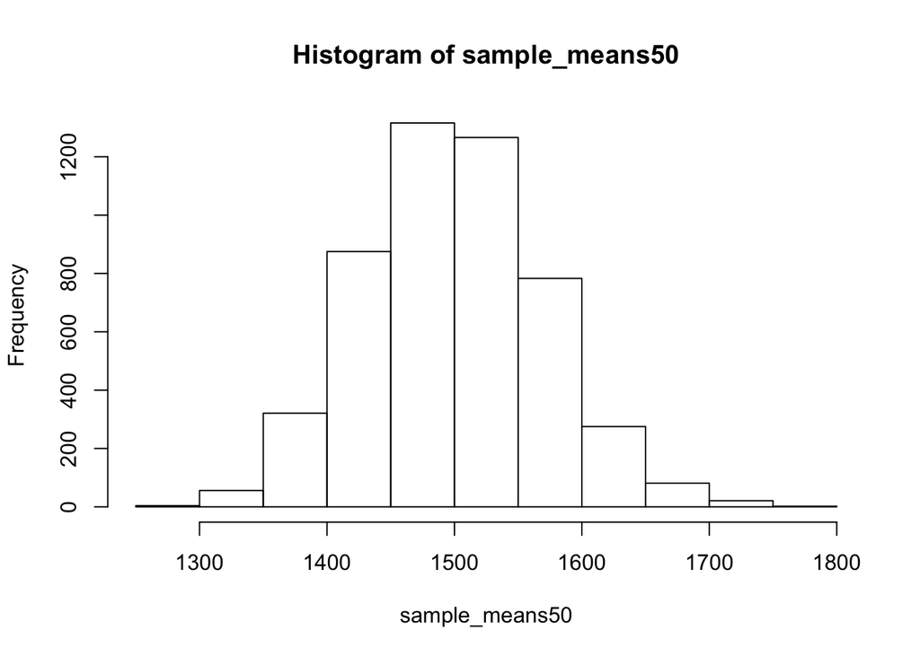

```r
hist(sample_means50)
```

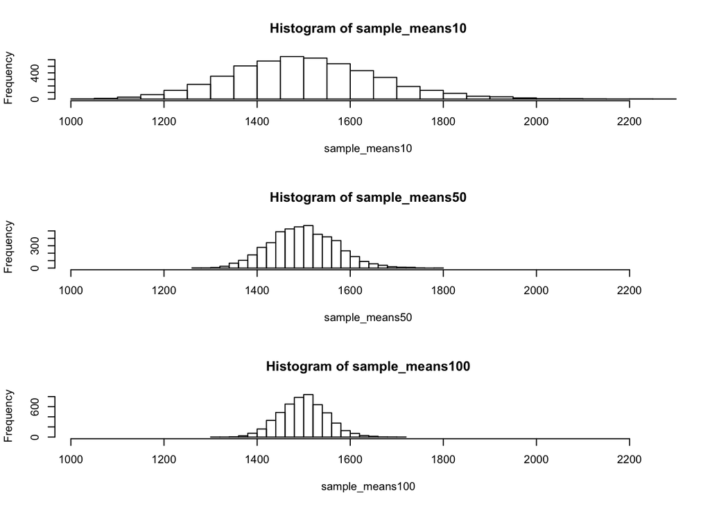

```r
sample_means10 <- rep(NA, 5000)
sample_means100 <- rep(NA, 5000)

for(i in 1:5000){
  samp <- sample(area, 10)
  sample_means10[i] <- mean(samp)
  samp <- sample(area, 100)
  sample_means100[i] <- mean(samp)
}
par(mfrow = c(3, 1))

xlimits <- range(sample_means10)

hist(sample_means10, breaks = 20, xlim = xlimits)
hist(sample_means50, breaks = 20, xlim = xlimits)
hist(sample_means100, breaks = 20, xlim = xlimits)
```

### Exercise 6

When the sample size is larger, what happens to the center? What about the spread?